# Reproducible Research: Peer Assessment 1

Rajat Gupta

May 20, 2017

# Loading and preprocessing the data

## 1. Load the data (i.e. read.csv())

Check whether the the **destfile** is present, if not download from the **fileURL** link. Analyzing the data using head and str functions.

```r
destfile <- "repdata%2Fdata%2Factivity.zip"

fileURL <- "https://d396qusza40orc.cloudfront.net/repdata%2Fdata%2Factivity.zip"

if (!file.exists(destfile))
  {download.file(fileURL ,destfile,method="auto") }

Activity <- read.csv(unz(destfile, "activity.csv"), header = TRUE)

head(Activity,6)
```

```
##   steps       date interval
## 1    NA 2012-10-01        0
## 2    NA 2012-10-01        5
## 3    NA 2012-10-01       10
## 4    NA 2012-10-01       15
## 5    NA 2012-10-01       20
## 6    NA 2012-10-01       25
```

```r
str(Activity)
```

```
## 'data.frame':    17568 obs. of  3 variables:
##  $ steps   : int  NA NA NA NA NA NA NA NA NA NA ...
##  $ date    : Factor w/ 61 levels "2012-10-01","2012-10-02",..: 1 1 1 1 1 1 1 1 1 1 ...
##  $ interval: int  0 5 10 15 20 25 30 35 40 45 ...
```

## 2. Process/transform the data (if necessary) into a format suitable for your analysis

Converting date column in date format.

```r
Activity$date <- as.Date(Activity$date)

head(Activity,6)
```

```
##   steps       date interval
## 1    NA 2012-10-01        0
## 2    NA 2012-10-01        5
## 3    NA 2012-10-01       10
## 4    NA 2012-10-01       15
## 5    NA 2012-10-01       20
## 6    NA 2012-10-01       25
```

# What is mean total number of steps taken per day?

## 1.Calculate the total number of steps taken per day

The total number of steps per day is calculated using the aggregate function having argument of sum.

```r
TotalStepsPerDay <- aggregate(Activity$steps ~ Activity$date,FUN = sum )

names(TotalStepsPerDay) <- c("Date", "Steps")

head(TotalStepsPerDay,6)
```

```
##         Date Steps
## 1 2012-10-02   126
## 2 2012-10-03 11352
## 3 2012-10-04 12116
## 4 2012-10-05 13294
## 5 2012-10-06 15420
## 6 2012-10-07 11015
```

## 2.If you do not understand the difference between a histogram and a barplot, research the difference between them. Make a histogram of the total number of steps taken each day

Creating histogram for total steps taken each day.

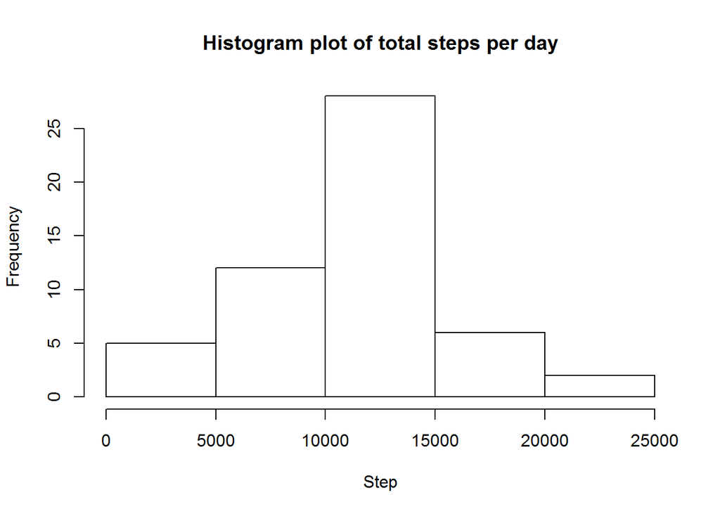

```r
hist(x = TotalStepsPerDay$Steps , xlab = "Step" ,main = "Histogram plot of total steps per day")
```

```r
Mean <- mean(TotalStepsPerDay$Steps, na.rm = TRUE)
```

```r
Median <- median(TotalStepsPerDay$Steps, na.rm = TRUE)
```

# What is the average daily activity pattern?

## 1.Make a time series plot (i.e. type = “l”) of the 5-minute interval (x-axis) and the average number of steps taken, averaged across all days (y-axis)

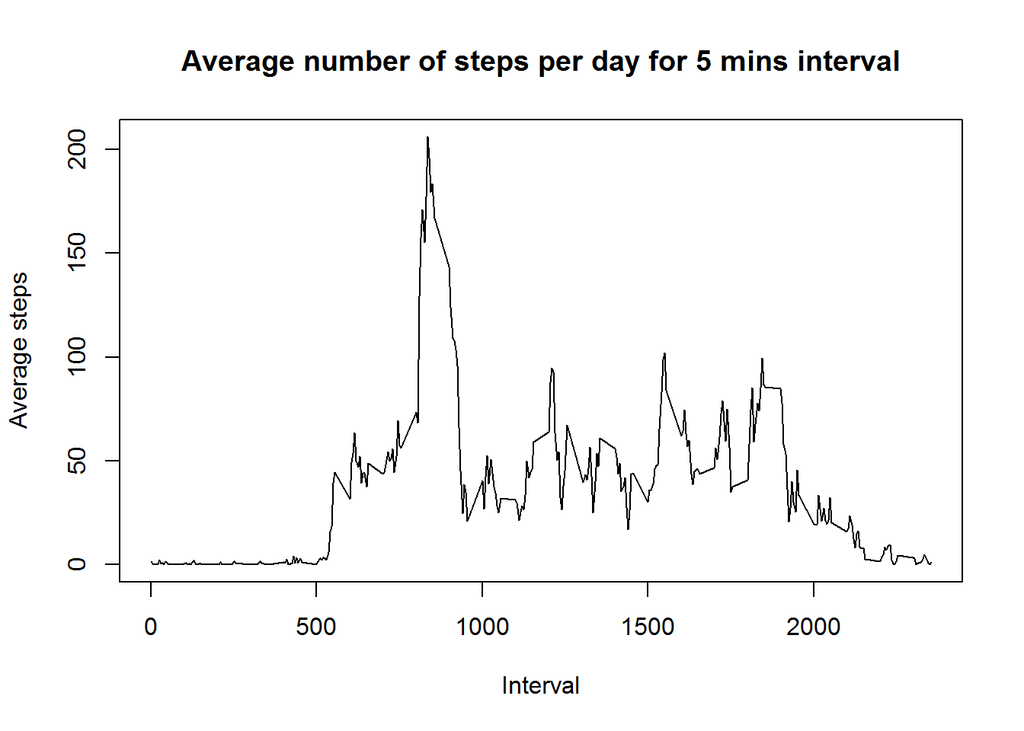

```r
Av.StepsbyInterval <- aggregate(Activity$steps ~ Activity$interval,FUN = mean )

names(Av.StepsbyInterval) <- c("Interval", "Average.Steps")

plot( x = Av.StepsbyInterval$Interval, y = Av.StepsbyInterval$Average.Steps ,
     type = "l" , main = "Average number of steps per day for 5 mins interval", xlab = "Interval",
     ylab = "Average steps")
```

```r
head(Av.StepsbyInterval,6)
```

```
##   Interval Average.Steps
## 1        0     1.7169811
## 2        5     0.3396226
## 3       10     0.1320755
## 4       15     0.1509434
## 5       20     0.0754717
## 6       25     2.0943396
```

## 2.Which 5-minute interval, on average across all the days in the dataset, contains the maximum number of steps?

```r
Max.Interval <-
Av.StepsbyInterval$Interval[which.max(Av.StepsbyInterval$Average.Steps)]
```

The maximum 5-minute interval, on average across all the days in the dataset is **835**

# Imputing missing values

Note that there are a number of days/intervals where there are missing values (coded as NA). The presence of missing days may introduce bias into some calculations or summaries of the data.

## 1.Calculate and report the total number of missing values in the dataset (i.e. the total number of rows with NAs)

```r
Missing.Values <- sum(is.na(Activity$steps))
```

The total number of missing values is **2304**.

## 2.Devise a strategy for filling in all of the missing values in the dataset. The strategy does not need to be sophisticated. For example, you could use the mean/median for that day, or the mean for that 5-minute interval, etc.

Here we are filling the missing interval data using verge interval data we obtained from previous parts. Combining next question solutions with 2.

## 3.Create a new dataset that is equal to the original dataset but with the missing data filled in.

Creating a Activity.NoNa variable which is initially equal to Activity data frame.

```r
Activity.NoNA <- Activity
```

```r
while( sum(is.na(Activity.NoNA$steps)) > 1)
{
  xyz <-  head(Activity.NoNA$interval[is.na(Activity.NoNA$steps)],1) ##Get the first interval value
  abc <-  head(which(is.na(Activity.NoNA$steps)), 1) ##Get the first row
  Activity.NoNA$steps[abc] <-Av.StepsbyInterval$Average.Steps [Av.StepsbyInterval$Interval == xyz]
  rm(xyz)
  rm(abc)
}

sum(is.na(Activity.NoNA$steps))
```

```
## [1] 1
```